# Assignment3-Natta-HotelBookingDemand

## Plot-4

### Type of hotel guests book and Type of hotel repeated guests book

### Interpretation:

- Below graph states which type of hotel the guests book the most using repeated guest as facets
- so new guests (repeated guests=0) tend to book higher than repeated guests(=1). new guests preferred city hotel over resort hotel and most of them are Transient type
- focusing more on repeated guests what they prefer booking(on sub-graph below), they prefer city hotel a little over resort hotel but difference is very small

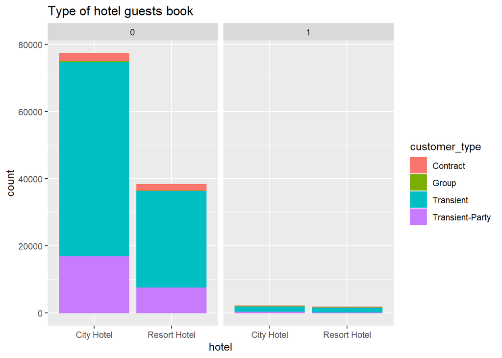

```r
ggplot(data=df) + geom_bar(mapping = aes(x = hotel, color = customer_type, fill=customer_type)) +
  ggtitle("Type of hotel guests book")+
  facet_wrap(~is_repeated_guest)
```

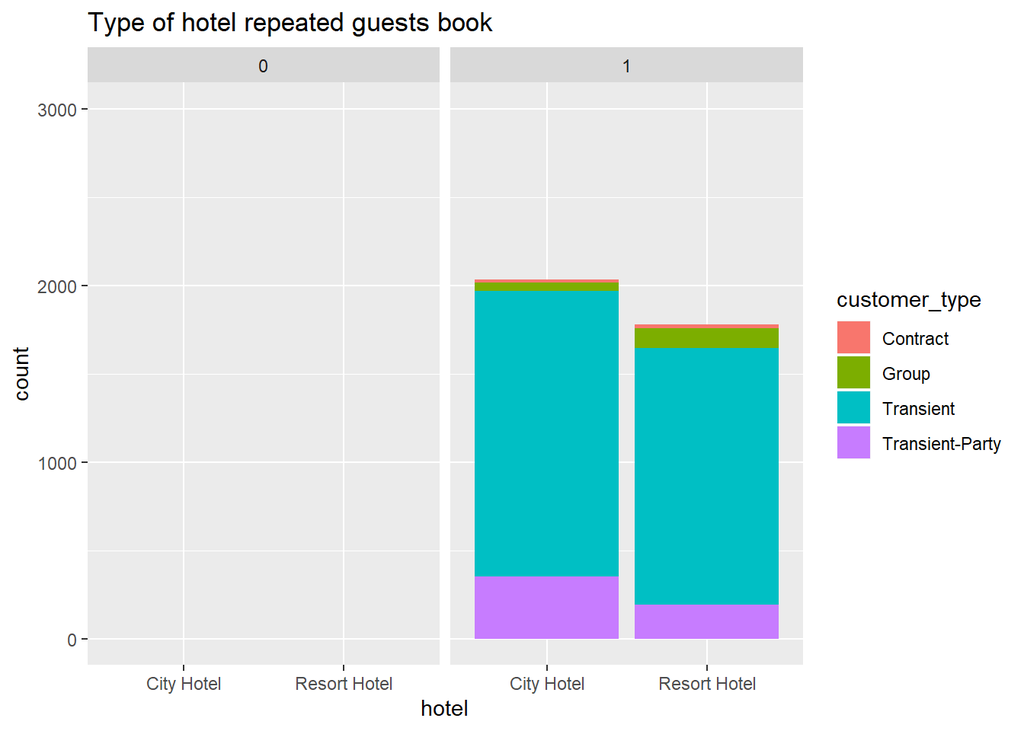

```r
ggplot(data=df) + geom_bar(mapping = aes(x = hotel, linetype = customer_type, fill = customer_type)) +
  ggtitle("Type of hotel repeated guests book")+
  facet_wrap(~is_repeated_guest)+ylim(0,3000)
```